# 1. Raw Data Analysis

The main goal is to get a first impression of the data and to determine which data cleaning steps are necassary.

### 1.1. General info about the data:

```
<class 'pandas.core.frame.DataFrame'>
RangeIndex: 1067371 entries, 0 to 1067370
Data columns (total 8 columns):
 #   Column       Non-Null Count    Dtype
---  ------       --------------    -----
 0   Invoice      1067371 non-null  object
 1   StockCode    1067371 non-null  object
 2   Description  1062989 non-null  object
 3   Quantity     1067371 non-null  int64
 4   InvoiceDate  1067371 non-null  object
 5   Price        1067371 non-null  float64
 6   Customer ID  824364 non-null   float64
 7   Country      1067371 non-null  object
dtypes: float64(2), int64(1), object(5)
memory usage: 65.1+ MB
```

|  | Invoice | StockCode | Description | Quantity | InvoiceDate | Price | Customer ID | Country |
| --- | --- | --- | --- | --- | --- | --- | --- | --- |
| 0 | 489434 | 85048 | 15CM CHRISTMAS GLASS BALL 20 LIGHTS | 12 | 2009-12-01 07:45:00 | 6.95 | 13085.0 | United Kingdom |
| 1 | 489434 | 79323P | PINK CHERRY LIGHTS | 12 | 2009-12-01 07:45:00 | 6.75 | 13085.0 | United Kingdom |
| 2 | 489434 | 79323W | WHITE CHERRY LIGHTS | 12 | 2009-12-01 07:45:00 | 6.75 | 13085.0 | United Kingdom |
| 3 | 489434 | 22041 | RECORD FRAME 7" SINGLE SIZE | 48 | 2009-12-01 07:45:00 | 2.10 | 13085.0 | United Kingdom |
| 4 | 489434 | 21232 | STRAWBERRY CERAMIC TRINKET BOX | 24 | 2009-12-01 07:45:00 | 1.25 | 13085.0 | United Kingdom |
| 5 | 489434 | 22064 | PINK DOUGHNUT TRINKET POT | 24 | 2009-12-01 07:45:00 | 1.65 | 13085.0 | United Kingdom |
| 6 | 489434 | 21871 | SAVE THE PLANET MUG | 24 | 2009-12-01 07:45:00 | 1.25 | 13085.0 | United Kingdom |
| 7 | 489434 | 21523 | FANCY FONT HOME SWEET HOME DOORMAT | 10 | 2009-12-01 07:45:00 | 5.95 | 13085.0 | United Kingdom |

### 1.2. Check for missing values:

```
Number of missing values per column:
Invoice             0
StockCode           0
Description      4382
Quantity            0
InvoiceDate         0
Price               0
Customer ID    243007
Country             0
dtype: int64

Number of affected rows: 243007
```

### 1.3. Analysis of values:

```
Number of unique customers: 5942
Number of unique products: 5305
Number of unique orders: 45336
Number of order cancellations: 8292
```

```
Non-numeric stock codes and their corresponding descriptions:
StockCode
ADJUST          [Adjustment by john on 26/01/2010 16, Adjustme...
ADJUST2                     [Adjustment by Peter on Jun 25 2010 ]
AMAZONFEE                                            [AMAZON FEE]
B                                               [Adjust bad debt]
BANK CHARGES                        [ Bank Charges, Bank Charges]
                                      ...
gift_0001_60                                                [nan]
gift_0001_70            [nan, Dotcomgiftshop Gift Voucher £70.00]
gift_0001_80            [nan, Dotcomgiftshop Gift Voucher £80.00]
gift_0001_90                                                [nan]
m                                                        [Manual]
Length: 62, dtype: object
```

### 1.4. Analysis of values (after dropping rows with missing customer ID):

```
Number of rows: 824364
Number of unique customers: 5942
Number of unique products: 4646
Number of unique orders: 36975
Number of order cancellations: 7901
```

```
Non-numeric stock codes and their corresponding descriptions:
StockCode
ADJUST          [Adjustment by john on 26/01/2010 16, Adjustme...
ADJUST2                     [Adjustment by Peter on Jun 25 2010 ]
BANK CHARGES                        [ Bank Charges, Bank Charges]
C2                                                     [CARRIAGE]
CRUK                                            [CRUK Commission]
D                                                      [Discount]
DOT                                              [DOTCOM POSTAGE]
M                                                        [Manual]
PADS                                 [PADS TO MATCH ALL CUSHIONS]
POST                                                    [POSTAGE]
SP1002                                   [KID'S CHALKBOARD/EASEL]
TEST001                                 [This is a test product.]
TEST002                                 [This is a test product.]
dtype: object
```

|  | Quantity | Price |
| --- | --- | --- |
| count | 824364.000000 | 824364.000000 |
| mean | 12.414574 | 3.676800 |
| std | 188.976099 | 70.241388 |
| min | -80995.000000 | 0.000000 |
| 25% | 2.000000 | 1.250000 |
| 50% | 5.000000 | 1.950000 |
| 75% | 12.000000 | 3.750000 |
| max | 80995.000000 | 38970.000000 |

### 1.5. Summary of Insights

- The dataset contains 1067371 rows, 243007 of which contain missing values.
- There are 62 non-numeric stock codes, which involve manual adjustments, postage, gift vouchers, test products and real products just to name a few.
- When dropping the rows with missing customer ID, there are only 13 of those non-numeric stock codes left, so dropping these rows seems highly benefitial in removing unwanted entries.
- After dropping the rows with missing customer ID, there are 824364 rows left comprising:
  - 5942 unique customers.
  - 4646 unique products.
  - 36975 unique orders.
  - 7901 order cancellations.
- Additional Notes:
  - Quantities also include negative values due to cancellations.
  - There are orders that are directly followed by their cancellation, for example the order with the minimum and maximum quantity
    - This should be corrected when cleaning the data, at least within a 14 day time window (UK's cooling-off period).
  - To generate a aggregated time series, the total price needs to be calculated (quantity * price).

# 2. Time Series Analysis

The main goal is to get general infos about the built time series and to get a first assessment of ARIMA orders (e.g. AR, MA and differencing order).

### 2.1. General info about the data:

The data set generated by the SalesForecastingPreprocessor is a time series including weekly aggregated sales.

```
<class 'pandas.core.frame.DataFrame'>
DatetimeIndex: 106 entries, 2009-12-06 to 2011-12-11
Data columns (total 1 columns):
 #   Column      Non-Null Count  Dtype
---  ------      --------------  -----
 0   TotalPrice  106 non-null    float64
dtypes: float64(1)
memory usage: 1.7 KB
```

### 2.2. Time series values

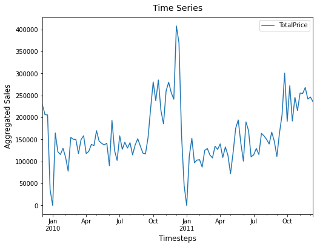

| InvoiceDate | TotalPrice |
| --- | --- |
| 2009-12-06 | 229181.530 |
| 2009-12-13 | 206294.190 |
| 2009-12-20 | 205820.440 |
| 2009-12-27 | 35306.040 |
| 2010-01-03 | 0.000 |
| 2010-01-10 | 164922.340 |
| 2010-01-17 | 121956.230 |
| 2010-01-24 | 115902.661 |

### 2.3. Measurements of time series values

|  | TotalPrice |
| --- | --- |
| count | 106.000000 |
| mean | 160109.196387 |
| std | 67237.883350 |
| min | 0.000000 |
| 25% | 117855.385000 |
| 50% | 143102.105000 |
| 75% | 193059.950000 |
| max | 407983.750000 |

### 2.4. Check zero Values

```
Zero values in time series: 2
```

| InvoiceDate | TotalPrice |
| --- | --- |
| 2010-01-03 | 0.0 |
| 2011-01-02 | 0.0 |

### 2.5. Check if time series is stationary:

Testing done with an augmented Dickey–Fuller (ADF) test and an Kwiatkowski–Phillips–Schmidt–Shin (KPSS) test.

- Case 1: Both tests conclude stationarity
- Case 2: Both tests conclude non-stationarity
- Case 3: When ADF concludes stationarity and KPSS concludes non-stationarity, the time series may be trend stationary
- Case 4: When ADF concludes non-stationarity and KPSS concludes stationarity, the time series may be difference stationary

```
ADF-Test (p=0.32), stationary: False
KPSS-Test (p=0.10), stationary: True
```

### 2.6. Estimate the differencing order:

```
Differencing order: 1
```

### 2.7. Plot differenced time series:

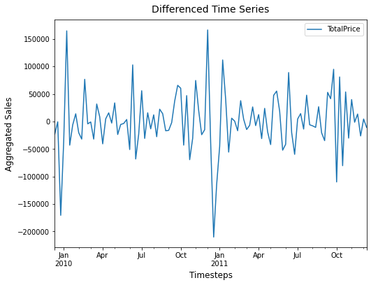

### 2.8. Inspect ACF and PACF plots:

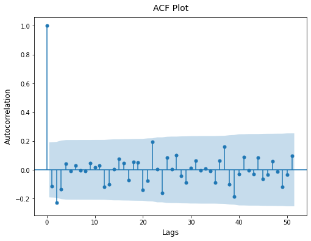

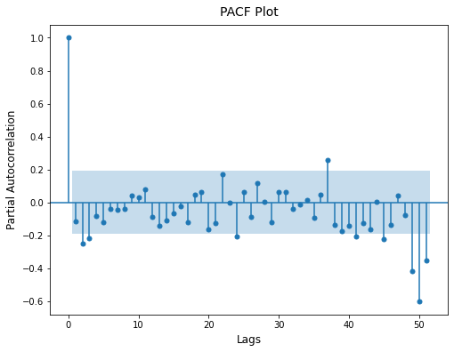

### 2.9. Summary of Insights

- The time series contains 106 weeks from 2009-12-06 to 2011-12-11.
  - There are also zero values included in the series, upon inspecting the data the shop seems to have company vacation between the 23.12 and 4.1
- According to the ADF test, the time series is not stationary and thus first differencing is recommended.
- Due to the small size of the data there is no obvious seasonal component, however looking at the general plot of the time series, it seems to have a repeating pattern every 52 weeks (1 year).
- Notes for ARIMA modeling
  - According to the ACF and PACF plot there is at least an AR(1) and an MA(1) component.
  - There are also relevant peeks around the 50 week mark indicating a seasonal AR(1) component.

# 3. Purchase Prediction Feature Analysis

The main goal is to figure out if there is any further feature engineering or preparation needed.

### 3.1. General info about the data:

The data set generated by the PurchasePredictionPreprocessor contains a feature set of five features, including

- recency: How recent is the last purchase in days (starting from the end of the defined timespan).
- frequency: How often did the customer purchase over the defined timespan.
- diff_purchase_t_1: Difference in days between the last purchase and the second last purchase.
- diff_purchase_t_2: Difference in days between the last purchase and the third last purchase.
- purchase_subsequent_quarters: How often did the customer purchase in two subsequent quarters.

The training data was calulate only for the quarters prior to the last one (2009-12-01 - 2011-09-30). The last quarter was used to generate the target labels (y_label), where the label 1.0 defines that the customer will purchases next quarter and the label 0.0 that the customer won't purchase next quarter. To make predctions with a model, the features are calculated over the whole time span (including the last quarter).

```
<class 'pandas.core.frame.DataFrame'>
Float64Index: 2775 entries, 12347.0 to 18287.0
Data columns (total 6 columns):
 #   Column                        Non-Null Count  Dtype
---  ------                        --------------  -----
 0   recency                       2775 non-null   int64
 1   frequency                     2775 non-null   int64
 2   diff_purchase_t_1             2775 non-null   float64
 3   diff_purchase_t_2             2775 non-null   float64
 4   purchase_subsequent_quarters  2775 non-null   float64
 5   y_label                       2775 non-null   float64
dtypes: float64(4), int64(2)
memory usage: 151.8 KB
```

| CustomerID | recency | frequency | diff_purchase_t_1 | diff_purchase_t_2 | purchase_subsequent_quarters | y_label |
| --- | --- | --- | --- | --- | --- | --- |
| 12347.0 | 59 | 6 | 54.0 | 117.0 | 3.0 | 1.0 |
| 12348.0 | 5 | 5 | 173.0 | 243.0 | 4.0 | 0.0 |
| 12352.0 | 2 | 7 | 8.0 | 190.0 | 1.0 | 1.0 |
| 12356.0 | 175 | 5 | 80.0 | 135.0 | 2.0 | 0.0 |
| 12358.0 | 80 | 4 | 225.0 | 400.0 | 0.0 | 1.0 |
| 12359.0 | 119 | 9 | 116.0 | 142.0 | 4.0 | 0.0 |
| 12360.0 | 42 | 5 | 88.0 | 280.0 | 2.0 | 1.0 |
| 12361.0 | 217 | 4 | 175.0 | 292.0 | 2.0 | 0.0 |

### 3.2. Measurements of feature values

|  | recency | frequency | diff_purchase_t_1 | diff_purchase_t_2 | purchase_subsequent_quarters |
| --- | --- | --- | --- | --- | --- |
| count | 2775.000000 | 2775.000000 | 2775.000000 | 2775.000000 | 2775.000000 |
| mean | 117.591712 | 8.805405 | 98.367207 | 180.325766 | 2.609009 |
| std | 129.103219 | 11.383954 | 92.052665 | 125.260207 | 2.143616 |
| min | 0.000000 | 3.000000 | 1.000000 | 2.000000 | 0.000000 |
| 25% | 18.000000 | 4.000000 | 31.000000 | 79.000000 | 1.000000 |
| 50% | 66.000000 | 6.000000 | 68.000000 | 153.000000 | 2.000000 |
| 75% | 182.000000 | 10.000000 | 134.000000 | 261.000000 | 4.000000 |
| max | 621.000000 | 207.000000 | 630.000000 | 656.000000 | 7.000000 |

### 3.3. Plot distribution of features as boxplots

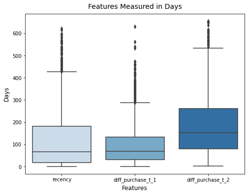

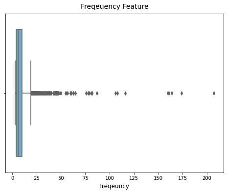

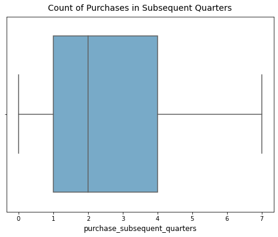

### 3.4. Check y-labels:

```
Label Counts:
0.0    1668
1.0    1107
Name: y_label, dtype: int64

Imbalance Ratio: 1.51
```

### 3.5. Check feature correlation and multicolinearity:

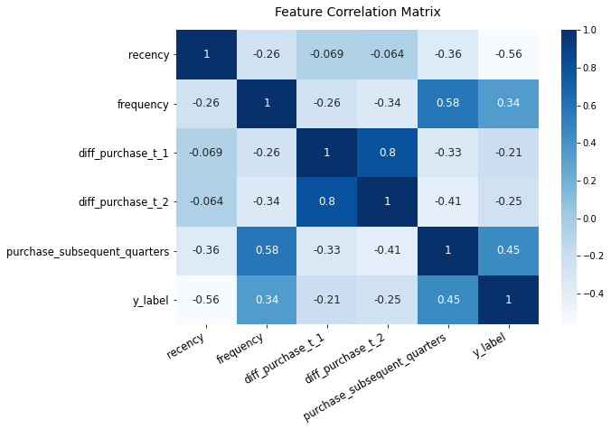

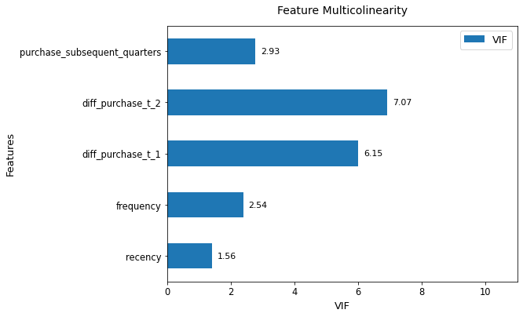

```
Features with high multicolinearity (>=10):
No features with high multicolinearity.
```

# 3. Product Recommender Data

The data set generated by the ProductRecommenderPreprocessor represents a binary customer-item matrix, where a cell **(i, j)** contains the value 1 if a customer **i** bought a product **j** nd a value 0 when the customer **i** did not buy product **j**.

```
<class 'pandas.core.frame.DataFrame'>
Float64Index: 5846 entries, 12346.0 to 18287.0
Columns: 4614 entries, 10002 to SP1002
dtypes: float64(4614)
memory usage: 205.8 MB
```

| CustomerID | 10002 | 10080 | 10109 | 10120 | 10123C | 10123G | 10124A | 10124G | 10125 | 10133 | ... | 90214R | 90214S | 90214T | 90214U | 90214V | 90214W | 90214Y | 90214Z | PADS | SP1002 |
| --- | --- | --- | --- | --- | --- | --- | --- | --- | --- | --- | --- | --- | --- | --- | --- | --- | --- | --- | --- | --- | --- |
| 12346.0 | 0.0 | 0.0 | 0.0 | 0.0 | 0.0 | 0.0 | 0.0 | 0.0 | 0.0 | 0.0 | ... | 0.0 | 0.0 | 0.0 | 0.0 | 0.0 | 0.0 | 0.0 | 0.0 | 0.0 | 0.0 |
| 12347.0 | 0.0 | 0.0 | 0.0 | 0.0 | 0.0 | 0.0 | 0.0 | 0.0 | 0.0 | 0.0 | ... | 0.0 | 0.0 | 0.0 | 0.0 | 0.0 | 0.0 | 0.0 | 0.0 | 0.0 | 0.0 |
| 12348.0 | 0.0 | 0.0 | 0.0 | 0.0 | 0.0 | 0.0 | 0.0 | 0.0 | 0.0 | 0.0 | ... | 0.0 | 0.0 | 0.0 | 0.0 | 0.0 | 0.0 | 0.0 | 0.0 | 0.0 | 0.0 |
| 12349.0 | 0.0 | 0.0 | 0.0 | 0.0 | 0.0 | 0.0 | 0.0 | 0.0 | 0.0 | 0.0 | ... | 0.0 | 0.0 | 0.0 | 0.0 | 0.0 | 0.0 | 0.0 | 0.0 | 0.0 | 0.0 |
| 12350.0 | 0.0 | 0.0 | 0.0 | 0.0 | 0.0 | 0.0 | 0.0 | 0.0 | 0.0 | 0.0 | ... | 0.0 | 0.0 | 0.0 | 0.0 | 0.0 | 0.0 | 0.0 | 0.0 | 0.0 | 0.0 |
| 12351.0 | 0.0 | 0.0 | 0.0 | 0.0 | 0.0 | 0.0 | 0.0 | 0.0 | 0.0 | 0.0 | ... | 0.0 | 0.0 | 0.0 | 0.0 | 0.0 | 0.0 | 0.0 | 0.0 | 0.0 | 0.0 |
| 12352.0 | 0.0 | 0.0 | 0.0 | 0.0 | 0.0 | 0.0 | 0.0 | 0.0 | 0.0 | 0.0 | ... | 0.0 | 0.0 | 0.0 | 0.0 | 0.0 | 0.0 | 0.0 | 0.0 | 0.0 | 0.0 |
| 12353.0 | 0.0 | 0.0 | 0.0 | 0.0 | 0.0 | 0.0 | 0.0 | 0.0 | 0.0 | 0.0 | ... | 0.0 | 0.0 | 0.0 | 0.0 | 0.0 | 0.0 | 0.0 | 0.0 | 0.0 | 0.0 |

8 rows × 4614 columns

```
Purchase count per customer:
```

```
CustomerID
12346.0     24.0
12347.0    126.0
12348.0     24.0
12349.0    137.0
12350.0     16.0
12351.0     21.0
12352.0     68.0
12353.0     23.0
dtype: float64
```